# Visualiser les comparaisons

# 1 Introduction

Dans cette partie, on a utiliser des graphiques pour faire des comparaisons.

On va comparer le niveau de gravité des accidents en fonction de deux variables

- situation des accidents en fonction des catégories des routes
- le sexe des usagers et la gravité des accidents
- l’âge des usagers et la gravité des accidents

# 2 Situation des accidents

Dans la partie précédente, on a évoqué la comparaison des situations des accidents en fonction des catégories des routes, on peut utiliser plusieurs barres empilées pour faire des comparaisons.

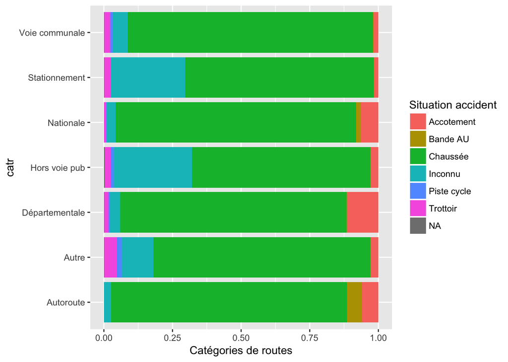

Ainsi sur le graphique précédent, on arrive à mieux comparer la composition des situations des accidents pour une catégorie de route donnée.

Cependant, on peut remarquer qu’il manque une information, c’est le volume. En effet, afin de mieux voir les proportion, on regarde les pourcentages. Dans la suite, on verra comment on peut visualiser les deux: le volume et le pourcentage.

# 3 Sexe et gravité

L’objectif est de voir les niveaux de gravité des accidents en fonction du sexe des conducteurs.

## 3.1 Sexe des conducteurs

- On peut d’abord comparer la gravité des accidents en fonction du sexe des conducteurs.
- Pour cela, on a d’abord filtrer les bases pour avoir uniquement les conducteurs.
- Ensuite, on peut comparer les niveaux d’accidents, en terme de nombres d’accidents.

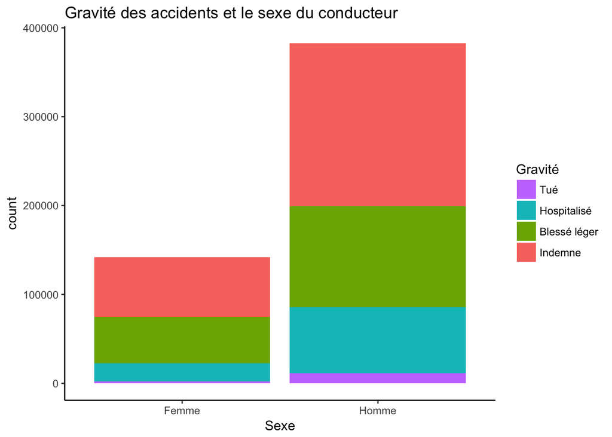

Afin de mieux comparer, on peut utiliser les pourcentages.

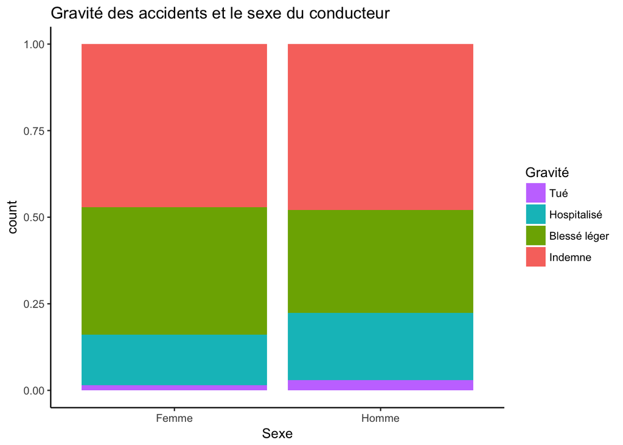

Comme évoqué précédement, on peut représenter à la fois le nombre et le pourcentage.

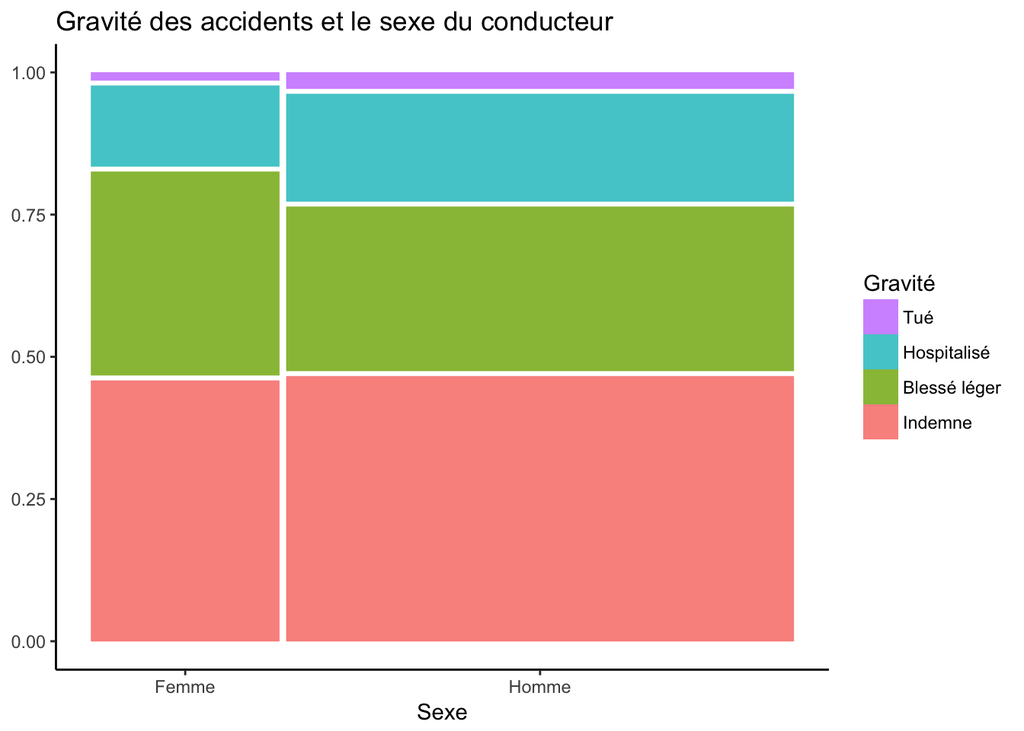

L’idée est d’avoir une comparaison visuelle, on peut aussi afficher les données brutes.

|  | Femme | Homme |
| --- | --- | --- |
| Indemne | 66952 | 183439 |
| Blessé léger | 52281 | 113607 |
| Hospitalisé | 20709 | 74317 |
| Tué | 2043 | 11233 |

Warning: quand on obtient le graphique précédent, on a parfois tendance à conclure que les hommes sont plus dangereux que les femmes. C’est peut-être vrai, mais on ne peut cependant pas conclure avec les seules données qu’on a. En effet, on ne connait pas le nombre total de conducteurs sur les routes selon le sexe.

## 3.2 Catégorie d’usagers

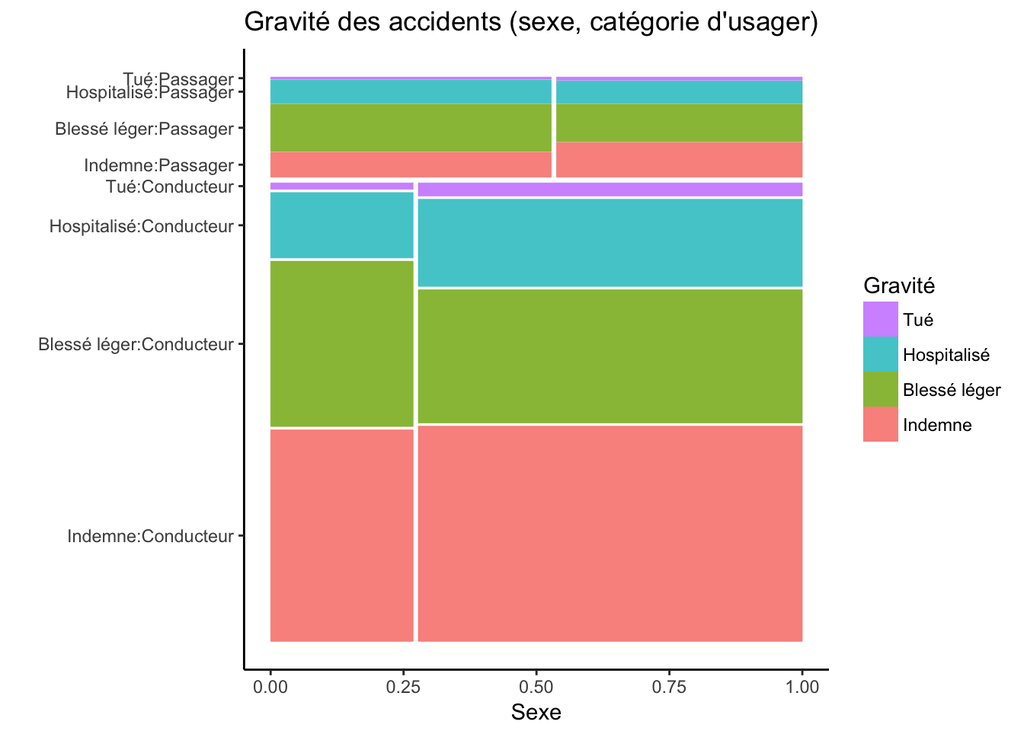

# 4 Ages et gravité

Après le sexe, on peut étudier le niveau de gravité en fonction de l’âge.

## 4.1 Histogramme des gravités

Comme l’âge est une variable continue, on peut créer un histogramme pour représenter le nombre d’accidents en fonction de la gravité (selon l’axe y) et l’âge (selon l’axe x).

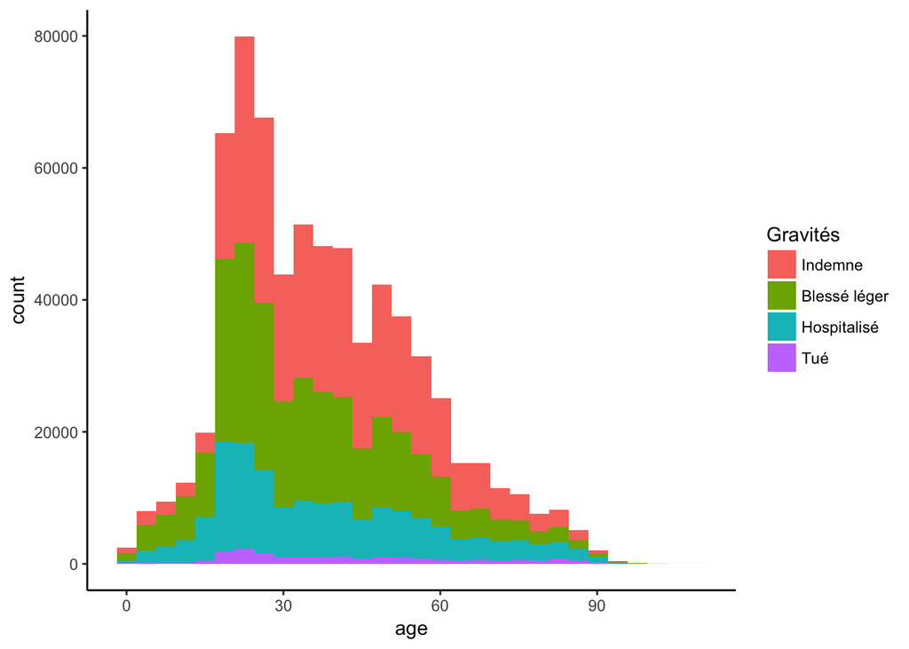

Pour mieux comparer, on peut représenter les pourcentages.

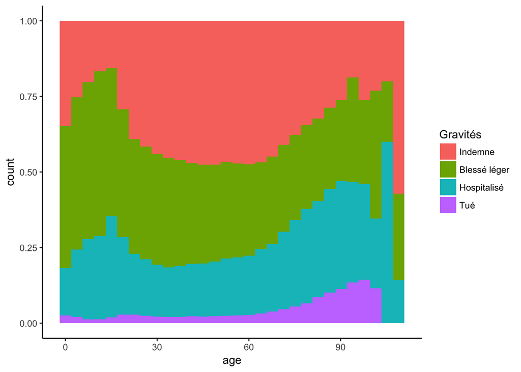

On peut cependant remarquer que le pourcentage n’est pas robuste quand le nombre n’est pas suffisant, notamment pour les âges élevés. Ainsi, il serait plus intéressant de faire des tranches d’âges.

## 4.2 Tranches d’âges

Pour une meilleure lisibilité, il convient de faire des tranches d’âges pertinentes. On peut définir quelques tranches en fonction de ce qu’on observe sur le graphique précédent.

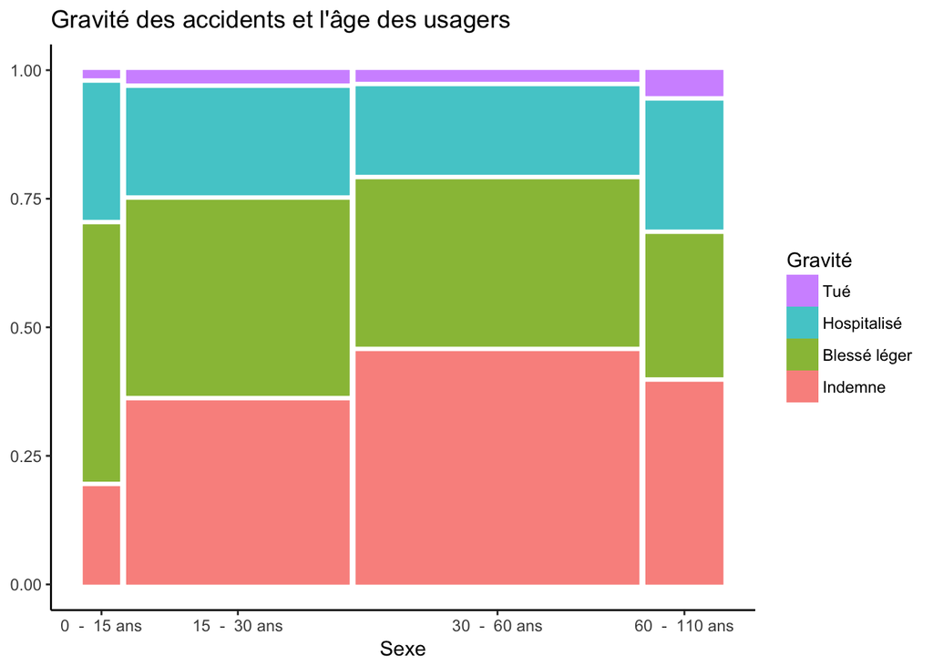

Ainsi, on voit le niveau de gravité des accidents en fonction principales tranches.

# 5 Streamgraph

On peut également créer un streamgraph, pour représenter les différents niveaux de gravité selon l’âge.

- Un streamgraph est normalement fait pour représentation l’évolution temporelle, ici on peut le “détourner” pour représenter le nombre d’accidents en fonction de l’âge.
- Les valeurs de l’axe x ont été modifiées: il faut soustraire 1000 pour avoir l’âge, par exemple 1030 représente 30 ans.
- On arrive ainsi à comparer le nombre d’accidents en fonction des niveaux de gravité pour un âge donné.

[interactive chart not shown]

Ce graphique est également utile pour représenter l’évolution temporelle, ce qui nous introduit à la partie suivante.